# DSA1101 Topic 4: K-Nearest Neighbours

Dawn Cheung

2024-03-04

## Definition of Terms

- has n number of training points
- features denoted as x
- categorical response is y
- with info x, the predicted y is Ĝ(x) [G hat (x)] or really y hat is fine too
- since we only consider binary responses (ie 0 or 1) only, the prediction Ĝ(x) is either 0 or 1 too

### KNN

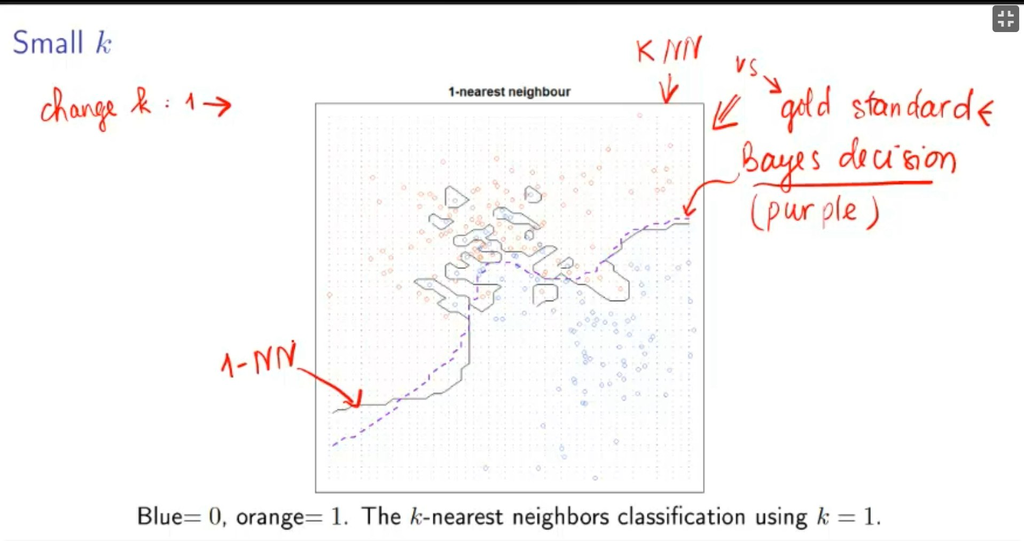

### Scaling x

```r
market <- read.csv("~/GitHub/DSA1101 Slayers/datasets/Smarket.csv")
attach(market)
Lag1 = scale(Lag1) # to standardise all the predictors (the x es)
```

To be done BEFORE APPLYING KNN

Will not be needed for stock market dataset cus lap1 to lap 5 are all *similar in magnitude* => will not change the outcome a lot

### Stock Market Dataset

Predicting the direction of the stock market: whether it goes up or down => 1 is up, 0 is down

knn() will require the following arguments:

- Matrix of predictors/features x for training
- Matrix of predictors/features x to be predicted
- Vector containing class labels for the training data
- Value for k (number of nearest neighbours for the classifier)

```r
# Enter code here
library(class)
library(dplyr)
market <- read.csv("~/GitHub/DSA1101 Slayers/datasets/Smarket.csv")
head(market)
```

```
##   X Year   Lag1   Lag2   Lag3   Lag4   Lag5 Volume  Today Direction
## 1 1 2001  0.381 -0.192 -2.624 -1.055  5.010 1.1913  0.959        Up
## 2 2 2001  0.959  0.381 -0.192 -2.624 -1.055 1.2965  1.032        Up
## 3 3 2001  1.032  0.959  0.381 -0.192 -2.624 1.4112 -0.623      Down
## 4 4 2001 -0.623  1.032  0.959  0.381 -0.192 1.2760  0.614        Up
## 5 5 2001  0.614 -0.623  1.032  0.959  0.381 1.2057  0.213        Up
## 6 6 2001  0.213  0.614 -0.623  1.032  0.959 1.3491  1.392        Up
```

```r
# we see that X is the row number,
# Lag 1 to 5, the percentage returns for the 5 prev days => these are our predictors
dim(market) #get no. rows and columns
```

```
## [1] 1250   10
```

```r
attach(market)
```

Gameplan:

- all years before 2005 (ie 2001 - 2004) will be training set
- year 2005 will be testing set

```r
#indexes of all the rows where Year < 2005
index.train = which(Year < 2005) #returns a vector

#create data frame that has all the rows before 2005
train.data = market[index.train, ] #REMEMBER THE ,] BC MARKET IS NOT A LIST, ITS A DATAFRAME so u need specify the rows and columns
# leave blank ie [index.train,(empty)] = returns all columns

#the rest of the rows go to test data
test.data = market[-index.train, ]

dim(train.data); dim(test.data) #dim is dimentions hehe
```

```
## [1] 998  10
```

```
## [1] 252  10
```

Getting arguments 1 and 2

```r
#now we're filtering by all the columns we're gonna use, for both test and train datasets. idk why we're doing this after spiltting them, OK NOW I GETS cus we're gonna split them further into predictors and responses hehe
#REMEMBER THESE ARE DATAFRAMES SO SPECIFY ROW AND COLUMN
train.x = train.data[ ,c("Lag1", "Lag2", "Lag3", "Lag4", "Lag5")]
test.x = test.data[ ,c("Lag1", "Lag2", "Lag3", "Lag4", "Lag5")]
```

Getting argument 3

```r
#now get the responses to train & test the algorithm
train.y = train.data[ ,c("Direction")]
test.y = test.data[ ,c("Direction")] #these are the 'real' responses, NOTE it is NOT needed for knn()
```

### OK WE FORMING THE MODEL NOW

```r
library(class)

knn.pred = knn(train.x, test.x, train.y, k = 1)

knn.pred #returns the prediction for the response of the test points i.e. predictions for text.x
```

```
##   [1] Down Up   Up   Down Down Down Up   Down Up   Down Up   Down Up   Down Down
##  [16] Up   Down Down Up   Down Up   Down Down Down Down Up   Up   Up   Up   Down
##  [31] Up   Down Down Up   Up   Down Up   Up   Up   Down Up   Up   Up   Up   Up
##  [46] Down Up   Down Up   Up   Up   Up   Down Down Down Up   Down Up   Down Up
##  [61] Down Up   Down Up   Down Up   Down Down Down Down Down Up   Down Up   Up
##  [76] Down Down Down Up   Down Up   Down Up   Down Up   Down Up   Up   Down Up
##  [91] Down Down Up   Up   Down Up   Down Down Down Up   Down Down Up   Up   Up
## [106] Up   Up   Down Down Down Up   Up   Up   Up   Up   Down Up   Down Up   Down
## [121] Up   Down Down Up   Up   Down Up   Down Up   Up   Up   Down Down Down Up
## [136] Up   Up   Up   Down Up   Down Up   Up   Up   Up   Down Down Down Up   Down
## [151] Up   Up   Down Down Up   Down Up   Down Up   Up   Up   Down Up   Up   Up
## [166] Up   Up   Up   Up   Down Up   Down Down Up   Up   Up   Up   Down Up   Down
## [181] Up   Down Down Down Down Down Down Up   Up   Up   Down Up   Down Down Down
## [196] Up   Up   Up   Down Down Up   Down Down Down Up   Down Down Up   Up   Down
## [211] Down Down Down Up   Down Down Up   Up   Down Down Down Up   Down Up   Up
## [226] Down Down Down Down Down Up   Up   Down Up   Down Down Up   Up   Up   Up
## [241] Down Up   Up   Up   Down Up   Up   Down Down Up   Up   Up
## Levels: Down Up
```

##### So how did the model do?

```r
data.frame(test.y, knn.pred) %>%
  slice(1:25) #lol to shorten the doc
```

```
##    test.y knn.pred
## 1    Down     Down
## 2    Down       Up
## 3    Down       Up
## 4      Up     Down
## 5    Down     Down
## 6      Up     Down
## 7    Down       Up
## 8      Up     Down
## 9    Down       Up
## 10     Up     Down
## 11     Up       Up
## 12   Down     Down
## 13   Down       Up
## 14   Down     Down
## 15   Down     Down
## 16     Up       Up
## 17     Up     Down
## 18     Up     Down
## 19   Down       Up
## 20     Up     Down
## 21     Up       Up
## 22     Up     Down
## 23   Down     Down
## 24     Up     Down
## 25   Down     Down
```

```r
table(test.y, knn.pred)
```

```
##       knn.pred
## test.y Down Up
##   Down   55 56
##   Up     66 75
```

#### Diagnostics

Evaluation of the classifier’s performance

More notations:

- For 2 class labels, C is positive and C’ (C prime) is negative
  - True Positive: predict C, when actually C
  - True Negative: predict C’, when actually C’
  - False Positive: predict C, when actually C’
  - False Negative: predict C’, when actually C

##### Confusion Matrix

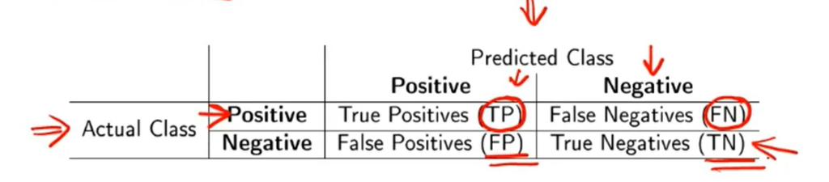

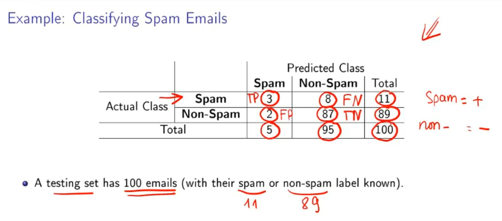

##### Criteria to Evaluate

- Accuracy
- True Positive Rate (TPR)
- False Positive Rate (FPR)– Type 1 Error
- False Negative Rate (FPR)– Type 2 Error
- Precision
- ROC curve & AUC value (will learn later)

##### Accuracy

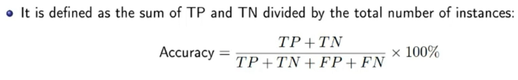

- The *overall success rate*
- Basically correct / total x 100%

##### True Positive Rate (TPR)

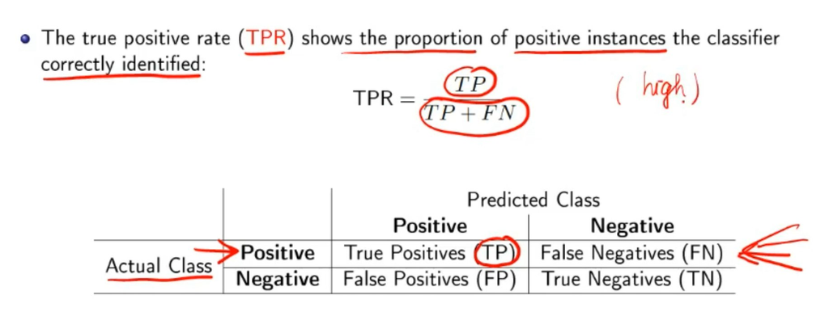

##### False Positive Rate (FPR)– Type 1 Error

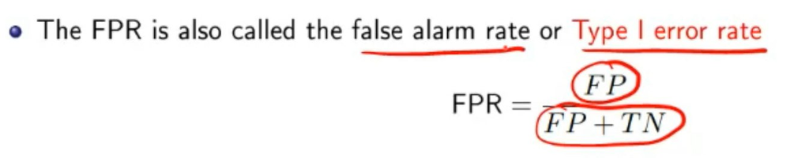

##### False Negative Rate (FNR)– Type 2 Error

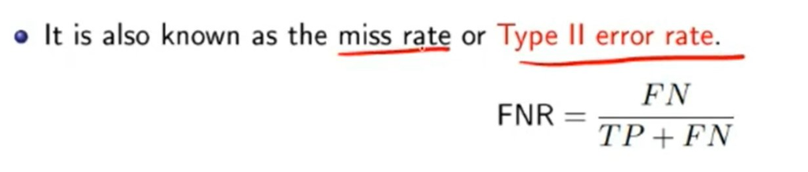

##### Precision

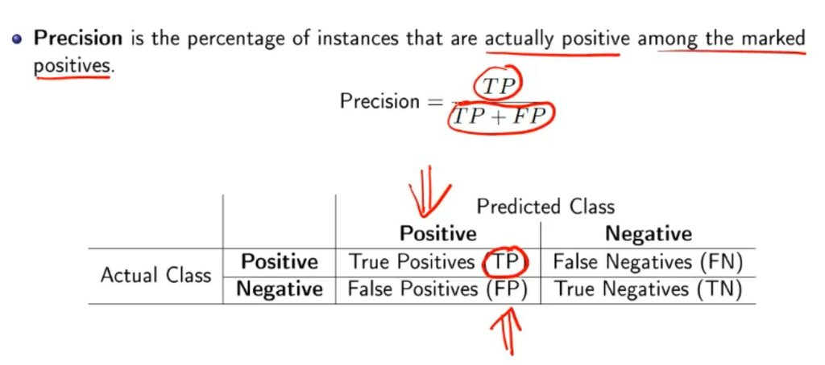

Odds ratio for 2 by 2 matrix:

[a b]

[c d]

OR = ad/bc

```r
slay <- function(x) {
  if (any(x == 0)){
    x = x + 0.5
  }
  return( (x[1,1]*x[2,2]) / (x[1,2]*x[2,1]) )
}

slay(cbind(c(1,2), c(3,4)))
```

```
## [1] 0.6666667
```

```r
#remember that cbind stands for column bind
#so all inputs will be put as new columns
```

k in knn is usually odd

### Accuracy

```r
knn.pred = knn(train.x, test.x, train.y, k = 5)
table(test.y, knn.pred)
```

```
##       knn.pred
## test.y Down Up
##   Down   50 61
##   Up     57 84
```

```r
knn.pred = knn(train.x, test.x, train.y, k = 10)
table(test.y, knn.pred)
```

```
##       knn.pred
## test.y Down Up
##   Down   52 59
##   Up     52 89
```